# Trees

Joseph Hejderup

2017-10-26

# Tree as a data structure

## Why organize data as a tree structure?

- Humans like hierarchies and *hierarchical* ordering. Examples are *family tree*, *governance*, *species*
- This form of systematic organization in a hierarchical order helps computers to localize and make decisions in a much more efficient way then linear data structures

## Example: Visiting a distant aunt

- You only meet her once every three years, she is from your dad’s side. There is a huge family gathering next week and you need to find her address. Learning from the previous lecture, the data is organized in this fashion

[figure not shown]

## Example: Visiting a distant aunt

If we structure the family in a tree, we can find it her address in less time, we know she is on the dad side, thus we avoid exploring half the family!

[figure not shown]

## Definition of a tree

[figure not shown]

## Tree terminology

- The **root** node does not have a **parent node**
- A **parent** node has zero, one or more **children**
- Certain nodes are both a parent and child
- Nodes on the same level, are *siblings*
- Each branch of the tree are disjoint and is a sub-tree of the tree

## Traversing a tree

There are three types of ways to traverse a tree

- Pre-order
- In-order
- Post-order

## Pre-order

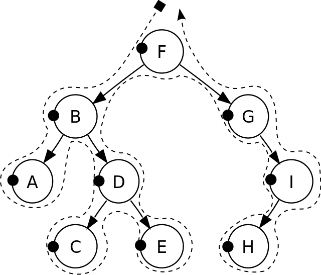

## In-order

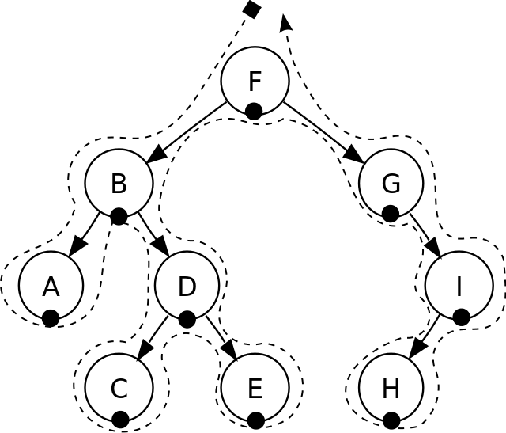

## Post-Order

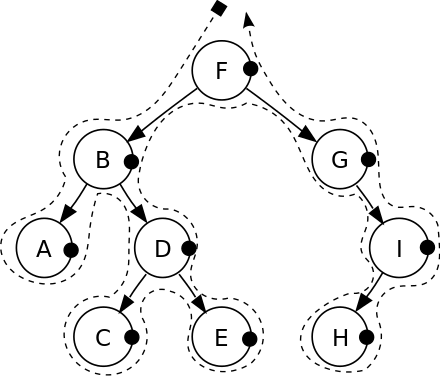

# Binary Trees

## Properties

## Binary Search Trees (BST)

## Searching in a Binary Search Tree

## Tree Manipulation

### Insertion

### Deletion

## Random Binary Tree

# Self-balancing binary search tree

## Treap

## AVL Tree

## WAVL Tree

## Scapegoat Tree

## Bibliography

## Copyright

This work is (c) 2017 - onwards by Georgios Gousios and licensed under the [Creative Commons Attribution-NonCommercial-ShareAlike 4.0 International](http://creativecommons.org/licenses/by-nc-sa/4.0/) license.